# decontam介绍

fuzhiliang

2023-08-14

# 1 前言

实验过程中，背景细菌的存在可能导致交叉污染，引起假阳性的发生，从而给mNGS结果解读带来困扰。mNGS专家共识中指出，实验室应该建立背景细菌库并定时更新，用于减少假阳性。

decontam通过浓度梯度（frequency）或阴性对照的方式（Prevalence）鉴定实验过程中的背景菌。因此本文旨在介绍decontam内部细节。

正文开始前，有如下注意事项：

- 本文主要集中于decontam原理解读，因此使用方法和结果解读不过多留恋，读者请参考[官方教程](https://benjjneb.github.io/decontam/vignettes/decontam_intro.html)。
- 下文只涉及官网教程中提到的两个算法（frequency和prevalence）的核心部分，细枝末节和其他算法略过不提。
- 案例数据和代码均摘自作者源码，同时结合自身理解。本人非数学科班出身，若理解有误，欢迎大家批评指正。

# 2 基本使用

```r
suppressPackageStartupMessages({
  library(rio)
  library(ggplot2)
  library(dplyr)
  library(decontam)
})
```

数据格式：行为样本，列为不同的变量。

```r
ps <- readRDS(system.file("extdata", "MUClite.rds", package="decontam"))
head(data.frame(ps@otu_table)[1:5, 1:5])
```

```
##                 Seq1 Seq2 Seq3 Seq4 Seq5
## P1101C01701R00  3502 8391    0  193 2838
## P1101C01702R00 12040  152    0 7924    0
## P1101C01703R00  9877 2401    0 4333    0
## P1101C08701R00  4035 5706    0  257 3161
## P1101C08702R00 12491 1444    0 4384  294
```

```r
# calculate contaminant
contamdf.freq <- isContaminant(ps, method="frequency", conc="quant_reading")
head(contamdf.freq)
```

```
##             freq prev       p.freq p.prev            p contaminant
## Seq1 0.323002694  549 1.000000e+00     NA 1.000000e+00       FALSE
## Seq2 0.098667396  538 1.000000e+00     NA 1.000000e+00       FALSE
## Seq3 0.003551358  160 1.135975e-18     NA 1.135975e-18        TRUE
## Seq4 0.067588419  519 9.999998e-01     NA 9.999998e-01       FALSE
## Seq5 0.045174743  354 1.000000e+00     NA 1.000000e+00       FALSE
## Seq6 0.040417101  538 1.000000e+00     NA 1.000000e+00       FALSE
```

结果最后一列即判定该变量或病原是否为背景菌。

详情见[官方教程](https://benjjneb.github.io/decontam/vignettes/decontam_intro.html).

# 3 两个算法

## 3.1 frequency

思路如下：

随着样本浓度的增加，文库中的背景菌测序时被”抽中”的概率下降，因此定量结果中背景菌占比会下降。因此，将某变量的丰度结果（y）和样本浓度（x）构建$y=-x+b$的线性模型。如果该模型较零模型（$y=\bar x$）具有显著差异（F检验，阈值默认0.1），则判定该变量为背景菌。

### 3.1.1 如何统计检验

算法基于F分布。F分布定义如下：

> $X\thicksim \mathcal{X}^2(n_1), \ Y\thicksim \mathcal{X}^2(n_2),X、Y独立$,则
> $$F=\frac{X/n_1}{Y/n_2} \thicksim F(n_1, n_2)$$

假设有一组数据如下：

```r
load('decontam_data.rdata')
head(freq_data)
```

```
##       logc       logf
## 1 7.947679 -1.9106629
## 2 8.666992 -0.6715281
## 3 8.527539 -0.8704869
## 4 7.112327 -1.6684781
## 5 8.261526 -0.6038552
## 6 8.677951 -0.9100405
```

logc和logf分别为样本的荧光定量结果对数化和定量丰度结果对数化。

frequency构建的两个个模型如下：

```r
lm1 <- lm(logf~offset(-1*logc), data=freq_data)   # y=-x+b
lm1
```

```
##
## Call:
## lm(formula = logf ~ offset(-1 * logc), data = freq_data)
##
## Coefficients:
## (Intercept)
##       6.679
```

```r
lm0 <- lm(logf~1, data=freq_data)                 # y=mean x
lm0
```

```
##
## Call:
## lm(formula = logf ~ 1, data = freq_data)
##
## Coefficients:
## (Intercept)
##      -1.315
```

模型lm1斜率$a=-1$,截距项$b=$ 6.679147. 模型lm0为$y=$ -1.3151673

绘制散点图如下：

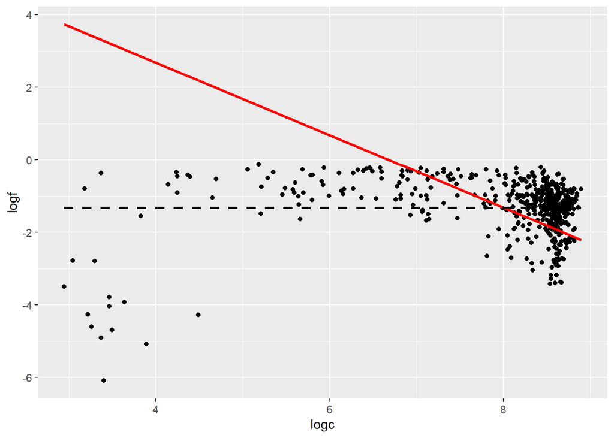

```r
freq_data %>%
  ggplot(aes(logc, logf))+
  geom_point()+
  geom_smooth(formula = 'y~offset(-1*x)', method = 'lm', color='red',linetype=1,se =F)+
  geom_smooth(formula = 'y~1', method = 'lm', color='black',linetype=2, se=F)
```

[figure not shown]

$SS_1, SS_0$分别表示拟合模型和零模型的残差平方和，服从F分布，进行F检验（左侧检验，$\alpha=0.1$）。

$$H_0: SS_1 \geq SS_0（lm1拟合效果劣于lm0,\ 为病原菌）\\
H_1:SS_1 < SS_0（lm1拟合效果优于lm0,\ 为背景菌）$$

计算统计量：

```r
dof <- nrow(freq_data)-1
SS1 <- sum(lm1$residuals^2)
SS0 <- sum(lm0$residuals^2)
F=SS1/SS0
F
```

```
## [1] 3.570293
```

计算上$\alpha$分位数：

```r
alpha <- 0.1
q <- qf(alpha, dof, dof)  # 左侧检验
q
```

```
## [1] 0.8962215
```

自由度$dof=$ 548的F分布图如下：

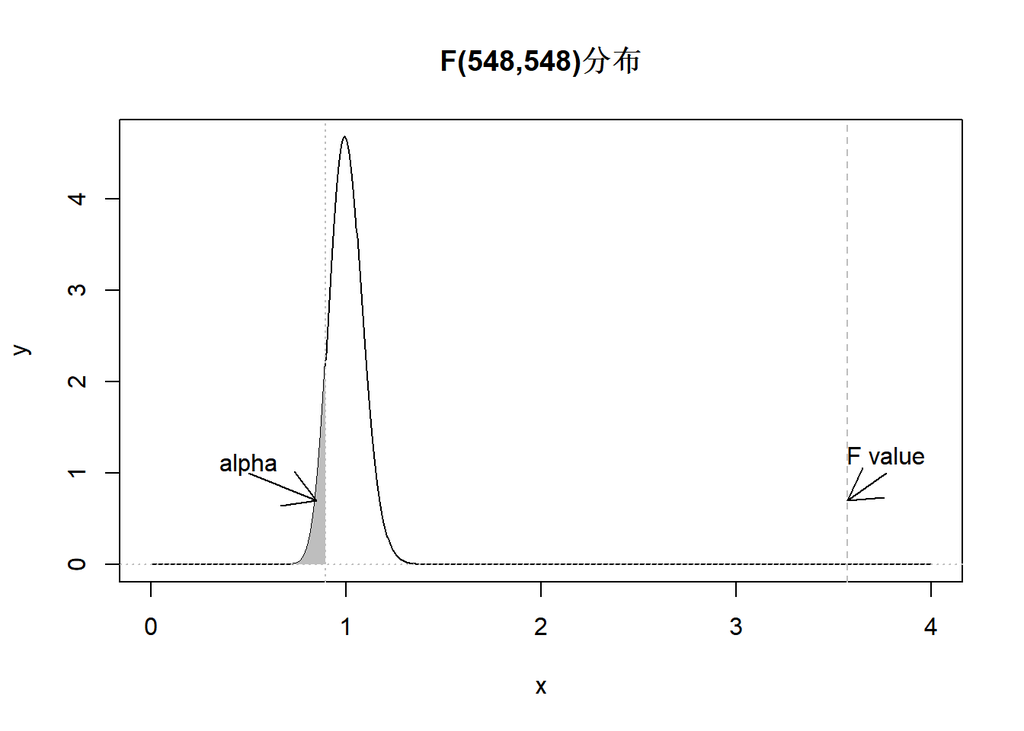

```r
x <- seq(0, 4,length = 1000)
y <- df(x, dof, dof)
plot(x, y, type="l", main=sprintf('F(%s,%s)分布',dof,dof))
abline(h=0, v=c(F,q), col="gray",lty=3:2)
# abline(, lty=3:2)

x_sub <- x[x < q]
y_sub <- y[x < q]
polygon(rbind(c(q,0),cbind(x_sub,y_sub)),border=NA,col="gray")
arrows(c(0.5,F+0.2), c(1,1), c(0.85,F), c(0.7,0.7))
text(c(0.5,F+0.2), c(1.1,1.2), labels=c('alpha','F value'))
```

```r
# dnorm_limit <- function(x){
#   y <- df(x, 589, 589)
#   y[x < 1.2] <- NA
#   return(y)
# }
# p <- ggplot(data.frame(x = c(0, 2)), aes(x = x))
# p +
#   stat_function(fun = dnorm_limit, geom = "area",
#                 fill = "red", alpha = 0.5) +
#   stat_function(fun = df, args = list(589,589))
```

左侧检验的拒绝域位于左侧小尾巴。统计量`F`大于上$\alpha$分位数，位于接受域，因此接受$H_0$，即该病原为病原菌。

计算p值：

```r
p <- pf(F, dof, dof)
p
```

```
## [1] 1
```

因为$p>0.1$，无法拒绝$H_0$，因此判定为病原菌。

## 3.2 Prevalence

frequency是根据浓度梯度构建丰度与荧光强度之间的线性关系，进而判定线性模型是否具有显著性。

更常见的做法是通过阴性对照样本判定该变量是否为背景菌。主要思路如作者所说，统计某个病原在测试组和阴性对照中中出现的比率，因此问题转换成两个样本比例的统计检验或fisher检验。

### 3.2.1 如何统计检验

定量数据转换成丰度，同时包含组别信息：

```r
head(preva_data)
```

```
##        Seq1   neg
## 1 0.1479823 FALSE
## 2 0.5109272 FALSE
## 3 0.4187476 FALSE
## 4 0.1885338 FALSE
## 5 0.5466999 FALSE
## 6 0.4025079 FALSE
```

Seq1为待检验的病原，neg指定组别，False表示为测试样本，True表示对照样本。

统计指标为该病原是否在样本中检出，因此构建2x2列联表如下：

```r
freq=factor(preva_data$Seq1>0, levels=c(TRUE, FALSE))
neg=factor(preva_data$neg, levels=c(TRUE, FALSE))
tab <- table(freq, neg)
tab
```

```
##        neg
## freq    TRUE FALSE
##   TRUE    12   537
##   FALSE   18     2
```

上述结果中，行表示是否在样本中检出，列指定是否为对照样本。阴性对照组中共30个样本，12个样本检出有该病原，因此比率为12/30。同理，测试组中99%(537/539)的样本检出该病原。

作者进行右侧检验，两个假设为（列联表中，行success表示病原，列success表示对照组，p表示病原菌的概率）：

$$H_0: 两个总体比率p_{nc} \leq p_{test}（病原菌） \\
H_1: 两个总体比率p_{nc} > p_{test}（背景菌）$$

```r
p=prop.test(tab, alternative="greater")$p.value
p
```

```
## [1] 1
```

右侧检验拒绝域位于右侧小尾巴。$p>0.1$位于接受域，因此接受$H_0$，即病原为病原菌。

# 4 小结

# 5 补充

## 5.1 测试数据

- 本文[测试数据地址](https://github.com/zhiliangfu/self-learning/tree/main/decontam)。

## 5.2 部分源码

Frequency:

```r
lm1 <- lm(logf~offset(-1*logc), data=df)
SS1 <- sum(lm1$residuals^2)
lm0 <- lm(logf~1, data=df)  # fit an intersept only
SS0 <- sum(lm0$residuals^2)
dof <- sum(freq>0)-1
pval <- pf(SS1/SS0,dof,dof)
```

Prevalence:

```r
fisher.pval <- function(tab, alternative) {
  excess <- fisher.test(tab, alternative="greater")$p.value +
    fisher.test(tab, alternative="less")$p.value - 1
  pval <- fisher.test(tab, alternative=alternative)$p.value
  pval <- pval - excess/2
  pval
}

pval <- tryCatch(
  prop.test(tab, alternative="greater")$p.value,
  warning=function(w) fisher.pval(tab, alternative="greater")
)
pval
```

# 6 拓展资料

- [官方教程](https://benjjneb.github.io/decontam/vignettes/decontam_intro.html).
- [源码包](https://bioconductor.org/packages/release/bioc/html/decontam.html).
- mNGS专家共识《高通量宏基因组测序技术检测病原微生物的临床应用规范化专家共识》